# Analysing the Domestic Violence Dataset from NFHS

Hrishant Singhal

Submitted to CEDA

All the data files that have been used in this data piece have been downloaded from [the CEDA data portal](https://ceda.ashoka.edu.in/data-portal/) and for the replication of code, they can be downloaded from [here](https://github.com/hrishantsinghal/CEDA-Project).

#### I analyse the domestic violence dataset from NFHS. It looks at currently married women and men aged 15-49 who agree with wife beating for any one of the following reasons:

1. If she goes out without telling him.
2. If she neglects the house or the children.
3. If she argues with him.
4. If she refuses to have sex with him.
5. If she doesn’t cook food properly.
6. If he suspects her of being unfaithful.
7. If she shows disrespect for in-laws.

### Men and Women have similar attitudes towards domestic violence

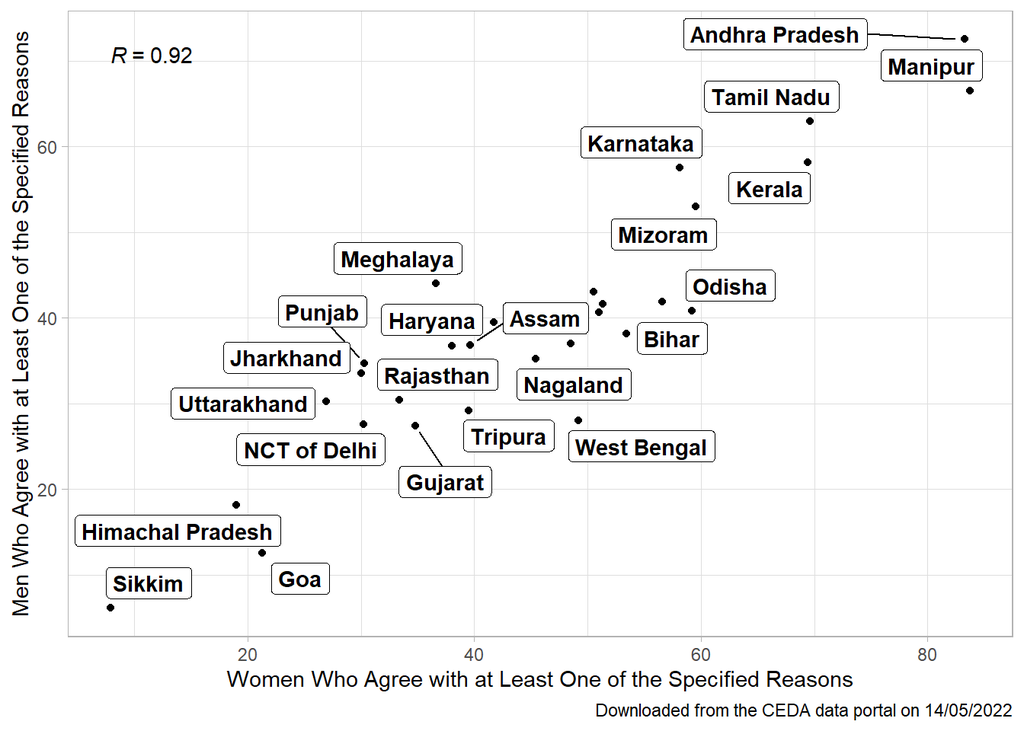

```r
#scatterplot of men and women attitudes
fdata %>% ggplot(aes(y=men16,x=women16,label=state)) +
  geom_point() +
  stat_cor(method = "pearson", aes(label = ..r.label..)) + ylab("Men Who Agree with at Least One of the Specified Reasons") +
  xlab("Women Who Agree with at Least One of the Specified Reasons")+
  geom_label_repel(aes(fontface = 'bold'),box.padding = unit(0.25, 'lines'),
                   point.padding = unit(0.5, 'lines'),max.overlaps = 10) +
  labs(caption = "Downloaded from the CEDA data portal on 14/05/2022")
```

### The averages have come down for both men and women from 2006 to 2016 but still a large percentage of men and women find domestic violence acceptable.

The averages have been calculated by giving equal weightage to each state and doesn’t take into account their population so the values would not be a true representation of India but is still useful in giving us an idea about the change from 2006 to 2016 and between males and females.

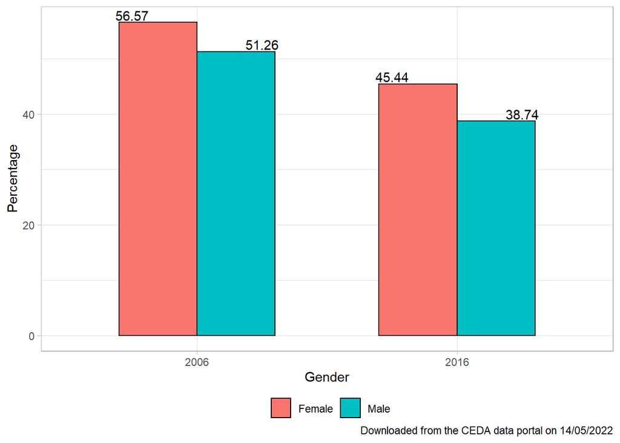

```r
#barplot of men and women average in 2006 and 2016
men_average_16<-round(mean(fdata$men16),2)
men_average_06<-round(mean(fdata$men06),2)
women_average_16<-round(mean(fdata$women16),2)
women_average_06<-round(mean(fdata$women06),2)

men_women_average<-data.frame (Gender  = c("Male", "Female"),
                                     Year = c("2006","2006","2016","2016"),
                               value=c(men_average_06,women_average_06,men_average_16,women_average_16)
)

men_women_average %>%
  ggplot(aes(y=value,x=Year,fill=Gender)) +
  geom_col(colour="black",width=0.6,
         position=position_dodge(0.6)) + ylab("Percentage") +
  xlab("Gender")+
  geom_text(aes(label=value),vjust=-0.2,position = position_dodge(width = 1)) +
  labs(caption = "Downloaded from the CEDA data portal on 14/05/2022")
```

### Change in Attitude from 2006 to 2016.

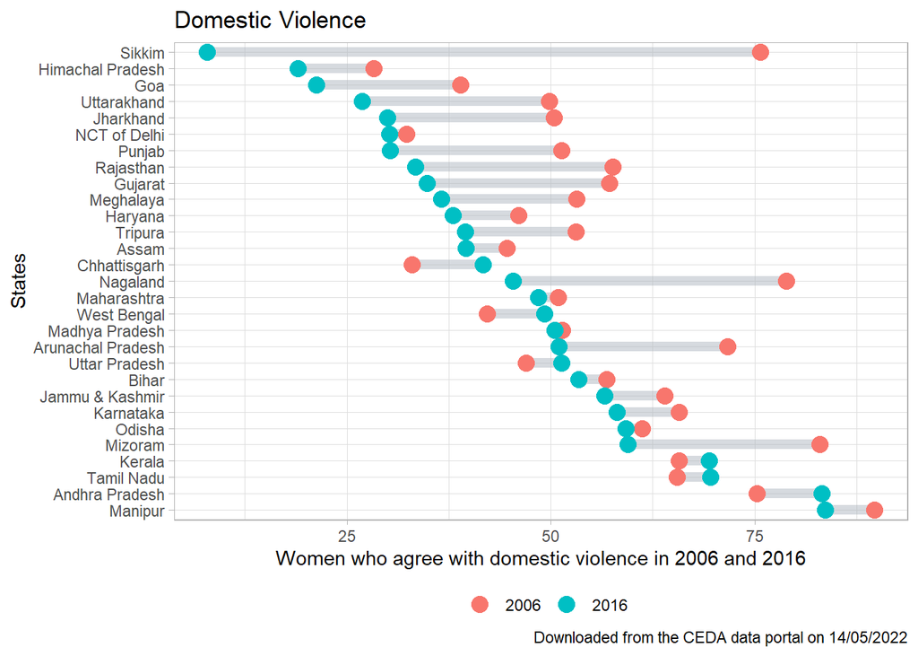

```r
#working on the arrowplot
arrow_reshape<-fdata %>% select(state,women06,women16) %>% melt() %>%
  mutate(year=ifelse(variable=="women06","2006","2016"))

w06 <- arrow_reshape %>%
  filter(year=="2006")
w16 <- arrow_reshape %>%
  filter(year=="2016") %>% mutate(state = fct_reorder(state, -value))

ggplot(arrow_reshape)+

  geom_segment(data = w16,
               aes(x = value, y = state,
                   yend = w06$state, xend = w06$value),
               color = "#aeb6bf",
               size = 2.5,
               alpha = .5) +
  geom_point(aes(x = value, y = state, color = year), size = 4, show.legend = TRUE) +
  ggtitle("Domestic Violence") + theme() +xlab("Women who agree with domestic violence in 2006 and 2016")+
  ylab("States") +
  labs(caption = "Downloaded from the CEDA data portal on 14/05/2022")
```

### Top 10 states where women agree with domestic violence. This plot has been grouped with the attitude of men from same states.

We again find that the values of men and women are very similar and in each of the top 10 states women agree more with domestic violence than a man.

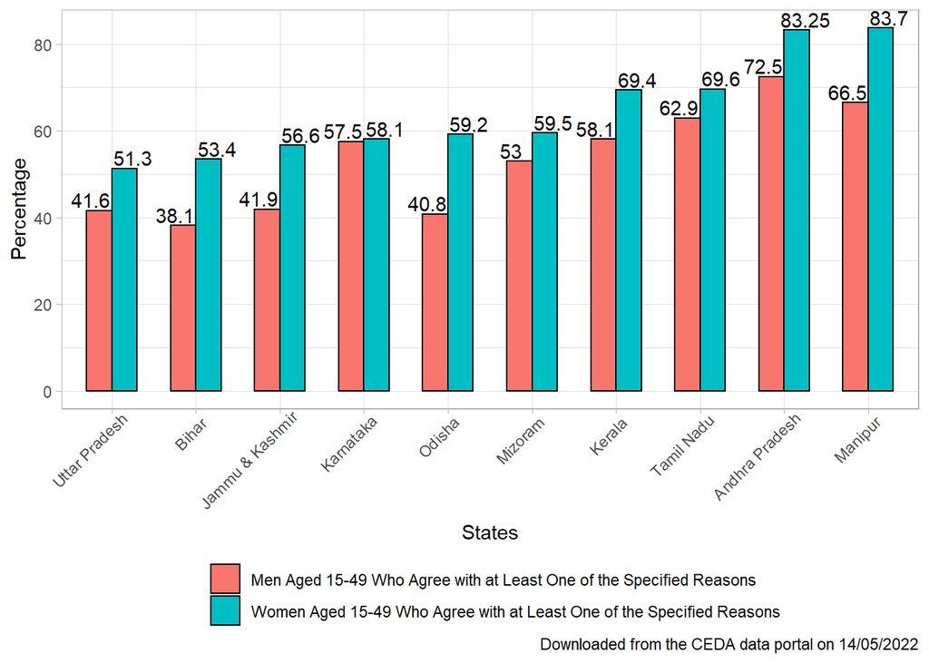

```r
#grouped bar plot men and women attitude towards domestic violence
men_women_2016<-fdata %>% mutate(state = reorder(state, women16)) %>%
  arrange(-women16) %>% top_n(10,women16) %>%
  select(state,
         `Men Aged 15-49 Who Agree with at Least One of the Specified Reasons`=men16,
         `Women Aged 15-49 Who Agree with at Least One of the Specified Reasons`=women16) %>%
  melt(id="state")

men_women_2016 %>%
  ggplot(aes(y=value,x=state,fill=variable)) +
  geom_col(colour="black",width=0.6,
         position=position_dodge(0.6)) + ylab("Percentage") +
  xlab("States")+theme(legend.position="bottom",legend.title = element_blank()) +
  geom_text(aes(label=value),vjust=-0.2,position = position_dodge(width = 1)) +
  guides(fill = guide_legend(nrow = 2)) +
  theme(axis.text.x = element_text(angle = 45, vjust = 1, hjust=0.9),
  legend.position = 'bottom',
  legend.box="vertical",
  legend.margin=margin(),
  legend.title = element_blank()) +
  labs(caption = "Downloaded from the CEDA data portal on 14/05/2022")
```

## Looking at reasons to explain why some states find domestic violence more acceptable than others.

### A. Education Level

Here is a grouped bar plot of states with the highest education and the attitude of women in that state towards domestic violence.

For education we have looked at percentage of people who had at least 8 years of schooling.

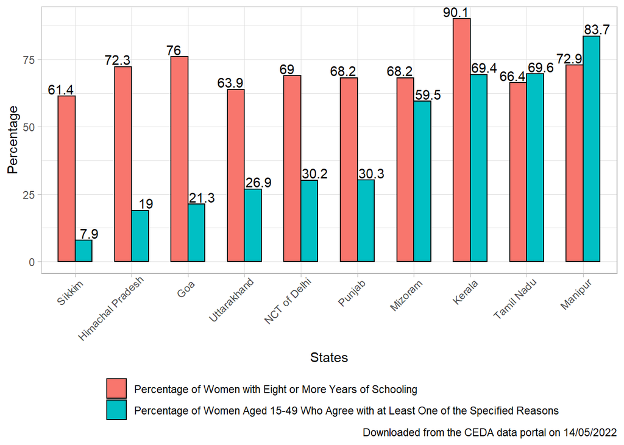

```r
#grouped bar plot of women education and their attitude towards domestic violence
w_edu_attitude<-fdata %>% mutate(state = reorder(state, women16)) %>%
  arrange(-womenabove8) %>% top_n(10,womenabove8) %>%
  select(state,
         `Percentage of Women with Eight or More Years of Schooling`=womenabove8,
         `Percentage of Women Aged 15-49 Who Agree with at Least One of the Specified Reasons`=women16) %>%
  melt(id="state")

w_edu_attitude %>%
  ggplot(aes(y=value,x=state,fill=variable)) +
  geom_col(colour="black",width=0.6,
         position=position_dodge(0.6)) + ylab("Percentage") +
  xlab("States")+
  geom_text(aes(label=value),vjust=-0.2,position = position_dodge(width = 1))+
  guides(fill = guide_legend(nrow = 2)) +
  theme(axis.text.x = element_text(angle = 45, vjust = 1, hjust=0.9),
  legend.position = 'bottom',
  legend.box="vertical",
  legend.margin=margin(),
  legend.title = element_blank()) +
  labs(caption = "Downloaded from the CEDA data portal on 14/05/2022")
```

This graph shows that even at higher levels of education, there are huge variations in terms of acceptance of domestic violence.

This scatter plot confirms that there is indeed no correlation between education and attitude towards domestic violence. Educated and uneducated women are equally likely to justify domestic violence.

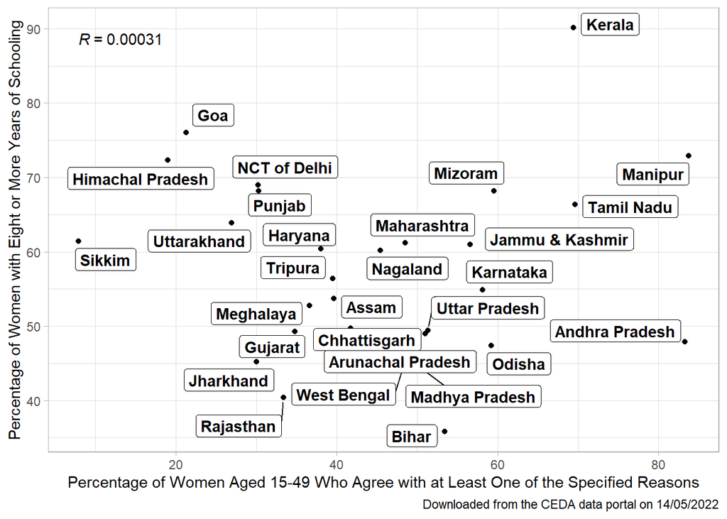

```r
fdata %>% ggplot(aes(y=womenabove8,x=women16,label=state)) +
  geom_point() +
  stat_cor(method = "pearson", aes(label = ..r.label..)) + ylab("Percentage of Women with Eight or More Years of Schooling") +
  xlab("Percentage of Women Aged 15-49 Who Agree with at Least One of the Specified Reasons")+
  geom_label_repel(aes(fontface = 'bold'),box.padding = unit(0.25, 'lines'),
                   point.padding = unit(0.5, 'lines'),max.overlaps = 10) +
  theme_light() +
  labs(caption = "Downloaded from the CEDA data portal on 14/05/2022")
```

### B. Women’s Participation in Decision Making

##### This NFHS data looks at currently married women aged 15-49 who have an equal or greater say in all the three following household decisions:

1. On their own health.
2. Visiting their parents.
3. Making major household purchases

We expect a significant negative correlation between ‘independence in decision making’ and ‘attitude towards domestic violence’. Women who are independent in decision making might not find wife-beating to be right.

Here is a scatter plot of independence in decision making and attitude towards domestic violence.

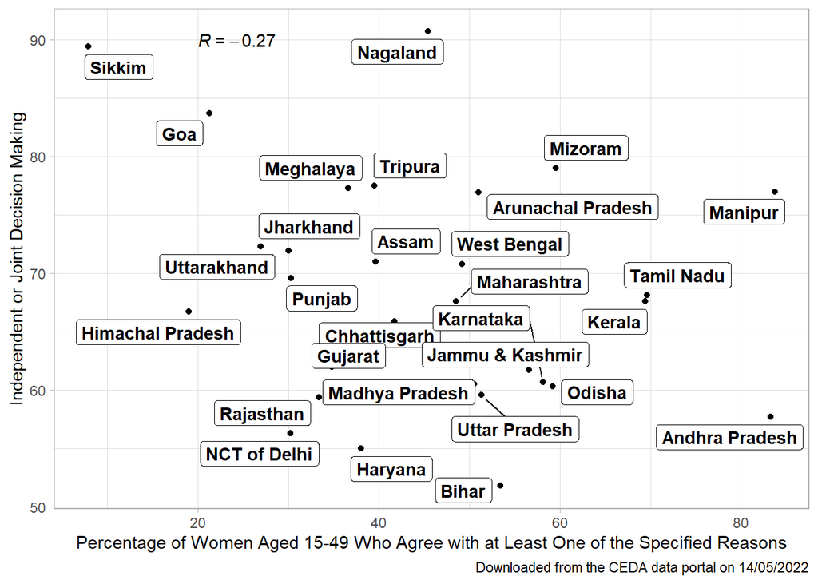

```r
#scatter plot of independence in decision making and attitude towards domestic violence.
fdata %>% ggplot(aes(y=wdecision,x=women16,label=state)) +
  geom_point() +
  stat_cor(method = "pearson", aes(label = ..r.label..),label.x=20,label.y=90) + ylab("Independent or Joint Decision Making") +
  xlab("Percentage of Women Aged 15-49 Who Agree with at Least One of the Specified Reasons")+
  geom_label_repel(aes(fontface = 'bold'),box.padding = unit(0.25, 'lines'),
                   point.padding = unit(0.5, 'lines'),max.overlaps = 10) +
  labs(caption = "Downloaded from the CEDA data portal on 14/05/2022")
```

As we can see there is nothing to indicate that states where women have a greater say in decision making believe that domestic violence is not acceptable.

### C. Income Levels

We expect women who have higher income levels to not agree with wife beating. We take the Average Monthly Consumption Expenditure of Women in various states and compare that with their attitude towards domestic violence.

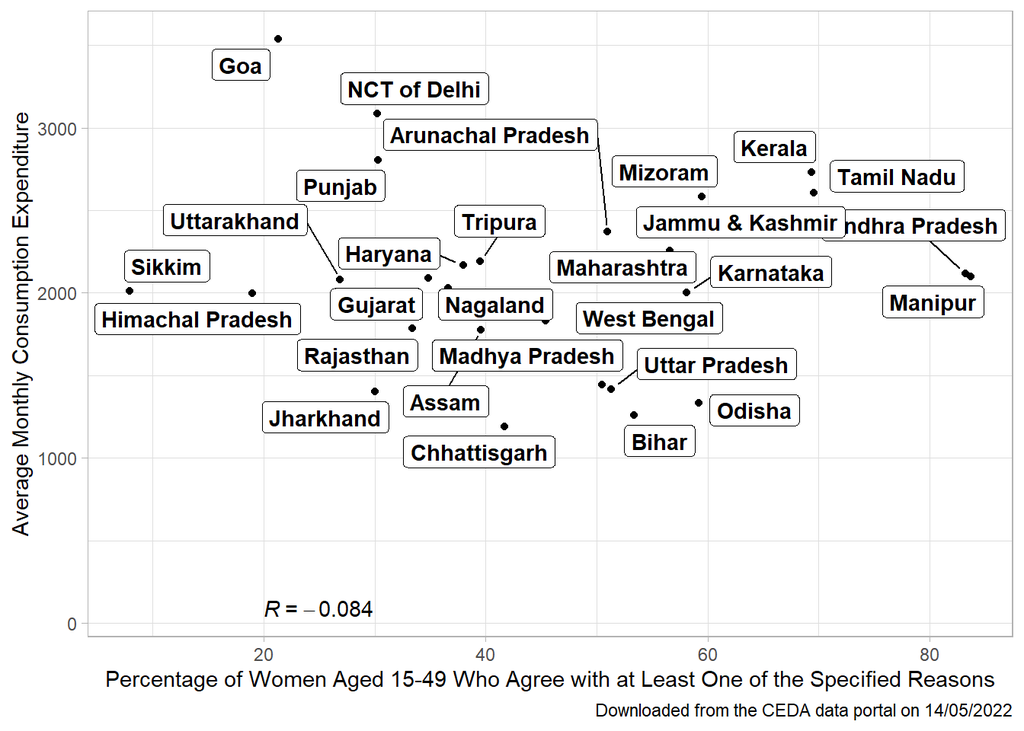

```r
#scatter plot of independence in consumption and attitude towards domestic violence.
fdata %>% ggplot(aes(y=mpce,x=women16,label=state)) +
  geom_point() +
  stat_cor(method = "pearson", aes(label = ..r.label..),label.x=20,label.y=90) + ylab("Average Monthly Consumption Expenditure") +
  xlab("Percentage of Women Aged 15-49 Who Agree with at Least One of the Specified Reasons")+
  geom_label_repel(aes(fontface = 'bold'),box.padding = unit(0.25, 'lines'),
                   point.padding = unit(0.5, 'lines'),max.overlaps = 10) +
  labs(caption = "Downloaded from the CEDA data portal on 14/05/2022")
```

We find no correlation which should not have been surprising since income levels are highly correlated with education and we had already seen that there was no correlation between education and attitude towards domestic violence.

## Conclusion

I tried looking at various factors that could have given us a hint about the background of women who agree with wife beating but could not find much. We saw that there is a high correlation between the attitudes of men and women in every state which might hint towards family background and traditions having an important role to play in their conditioning.

It is an ongoing study and I hope to dig deeper into it with time.